# Exam 1 Solutions

Your name

2026-09-28

*Note: For this exam, don’t worry about including the correct labels and titles for the plots.*

(30 possible points)

### Question 1.

Load the data called riverton-crime.csv using the proper R command and file path. What is this dataset about, according to the codebook? (Keep it short.)

**Your code (2 points):**

```r
dat <- read_csv("/Users/mariacuellar/Github/crim_data_analysis/data/riverton-crime1.csv")
```

**Your text answer (2 points):**

This dataset is about crime in Riverton, a mid-sized U.S. city. The Riverton Department of Public Safety created a dataset of 500 individuals whose criminal cases were resolved between 2022 and 2025.

### Question 2.

What types of variables are these? Variables: id, gender, offense_type, num_prior_arrests, and time_served_months.

**Your text answer (2 points):**

- id: Identifier
- gender: Categorical
- offense_type: Categorical
- num_prior_arrests: Quantitative
- time_served_months: Quantitative

### Question 3.

What percentage of the sample is male? How many females, males, and total individuals are there in this sample?

**Your code (2 points):**

```r
dat %>% count(gender) %>% mutate(prop = prop.table(n))
```

```
## # A tibble: 2 × 3
##   gender     n  prop
##   <chr>  <int> <dbl>
## 1 Female   122 0.244
## 2 Male     378 0.756
```

**Your text answer (2 points):**

75.6% of the sample is male. There are 122 females, 378 males, and 500 individuals total.

### Question 4.

Draw a plot to study the variable offense_type and describe it.

**Your code (2 points):**

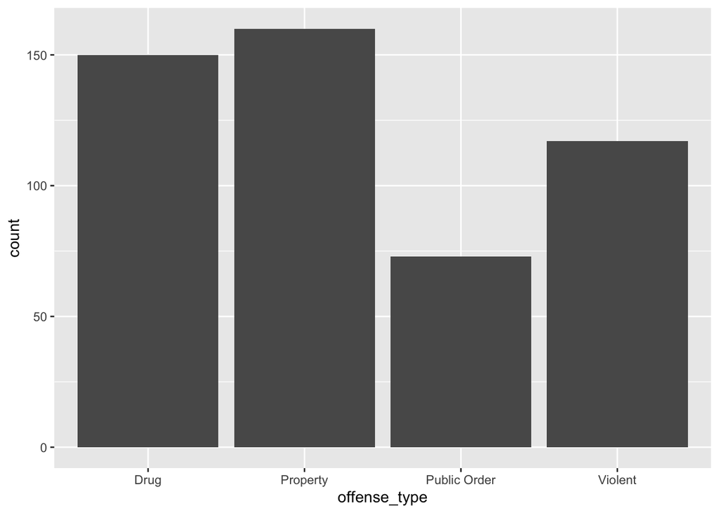

```r
dat %>% ggplot(aes(x=offense_type)) + geom_bar()
```

**Your text answer (2 points):**

The most common offense type is Property crime, then drug, then violent, and then public order, which is about half the cases of property.

### Question 5.

Now we are going to study the variable num_prior_arrests.

Perform visual EDA on num_prior_arrests. Adjust the number of bins so that the shape of the distribution is reasonably clear.

**Your code (2 points):**

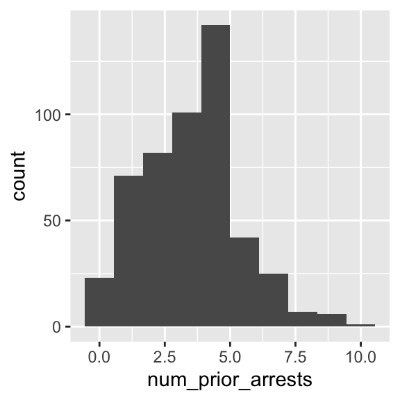

```r
dat %>% ggplot(aes(x=num_prior_arrests)) + geom_histogram(bins=10)
```

### Question 6.

Describe this plot.

**Your text answer (2 points):**

Unimodal, asymmetric, skewed right, no outliers.

### Question 7.

Find summary statistics to describe the centrality and spread of the variable num_prior_arrests. Which is the centrality and which is the spread? Explain what these values mean for this variable.

**Your code (2 points):**

```r
# It's a little difficult to see whether one tail is longer than the other, but it looks asymmetric. I'll check whether mean and median are different.
summary(dat$num_prior_arrests)
```

```
##    Min. 1st Qu.  Median    Mean 3rd Qu.    Max.
##   0.000   2.000   3.000   3.432   5.000  10.000
```

```r
# The distribution is asymmetric, so I will use the median and IQR as measures of centrality and spread.
dat %>% summarize(median = median(num_prior_arrests),
                  IQR = IQR(num_prior_arrests))
```

```
## # A tibble: 1 × 2
##   median   IQR
##    <dbl> <dbl>
## 1      3     3
```

**Your text answer (2 points):**

The median is 3 prior arrests, meaning half of the individuals have 3 or fewer prior arrests and half have 3 or more. The IQR is 3 arrests, meaning the middle 50% of observations span a range of 3 prior arrests. Centrality is median and spread is IQR.

### Question 8.

Now we will study the variable time_served_months. What is this variable measuring? Visualize this variable by drawing a plot.

**Your code (2 points):**

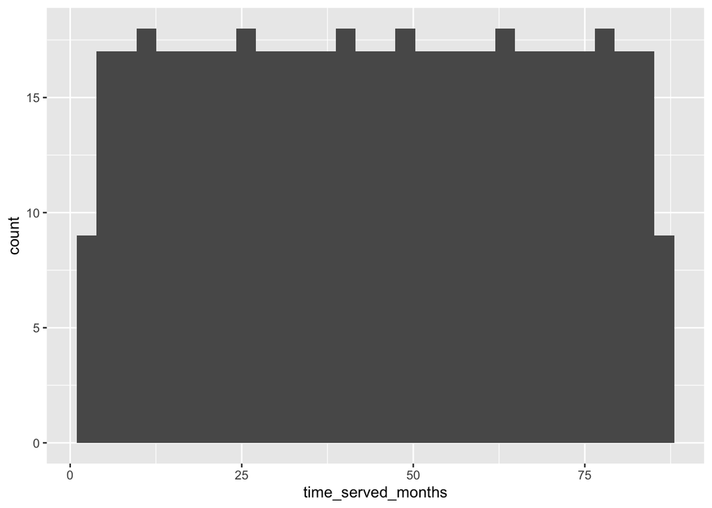

```r
dat %>% ggplot(aes(x=time_served_months)) + geom_histogram()
```

**Your text answer (2 points):**

The number of months the individual served for the current case.

### Question 9.

Describe the shape of the distribution. Then perform quantitative EDA on it.

**Your code (2 points):**

```r
dat %>% summarize(range = max(time_served_months) - min(time_served_months))
```

```
## # A tibble: 1 × 1
##   range
##   <dbl>
## 1  84.2
```

**Your text answer (2 points):**

This variable has a uniform distribution with a range of 84.2 months.

### Extra credit:

Describe what this code does. Why do the points appear in vertical columns rather than being spread continuously across the x-axis?

**Your code (1 point):**

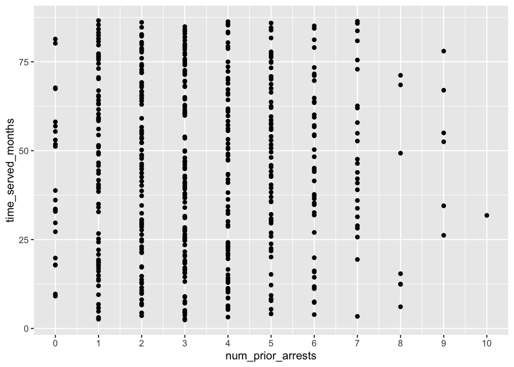

```r
dat %>%
  ggplot(aes(x = num_prior_arrests, y = time_served_months)) +
  geom_point() +
  scale_x_continuous(breaks = seq(
    min(dat$num_prior_arrests),
    max(dat$num_prior_arrests),
    by = 1
  ))
```

**Your text answer (1 point):**

num_prior_arrests is a discrete quantitative variable that takes only whole-number values. Therefore, observations with the same number of prior arrests have the same x-coordinate and line up vertically.